# Repeated Measures ANOVA

ChatGPT 4o

2025-01-21

## 1 起源

重复测量方差分析（Repeated Measures ANOVA）是一种用于处理重复测量数据的统计方法，起源于传统的方差分析技术。最早的方差分析由罗纳德·费舍尔（Ronald A. Fisher）提出，用于比较多个组之间的差异。随着实验设计的复杂化，重复测量方差分析逐渐被引入，以分析同一组个体在多个时间点或条件下的变化，从而控制个体间的差异。

## 2 原理

重复测量方差分析的核心思想是比较同一组对象在不同条件下的均值差异。与独立组方差分析不同，重复测量方差分析在控制个体间差异方面更具优势，因为数据来自相同的个体，因此个体差异作为误差源得以排除。

假设检验的步骤包括：

- **原假设（$H_0$）**：不同条件下的均值相等，即不存在显著差异。
- **备择假设（$H_1$）**：至少有一个条件下的均值与其他条件不同。

重复测量方差分析的总变异可以分解为：

- **组内变异**：即个体在不同测量条件下的差异。
- **组间变异**：即不同个体之间的差异，这部分在重复测量中被控制。

通过计算F值并与F分布的临界值进行比较，可以判断不同条件下的均值是否存在显著差异。

## 3 适用范围

重复测量方差分析适用于以下情况：

- **同一组个体在多个时间点的测量**：例如，测量治疗前、中、后的血压水平。
- **同一组个体在不同条件下的表现**：例如，测试学生在不同学习方法下的成绩。
- **数据满足正态性和方差齐性**：重复测量的差值应该符合正态分布，并且各个测量条件的方差相等。

## 4 应用情境

重复测量方差分析在实际应用中有着广泛的应用，例如：

- **医学研究**：比较病人在治疗前、中、后血糖水平的变化，评估治疗效果。
- **心理学实验**：分析受试者在不同刺激条件下的反应时间，以判断刺激效应。
- **教育研究**：比较同一组学生在不同教学方法下的学习效果。
- **运动科学**：评估运动训练前后某项体能指标的变化。

## 5 优缺点

### 优点

- **控制个体间差异**：由于使用的是相同个体的数据，重复测量方差分析可以有效控制个体间的差异，提高统计效能。
- **更少的受试者需求**：由于个体重复使用，相比独立组设计，重复测量设计需要更少的受试者。

### 缺点

- **对顺序效应敏感**：测量顺序可能影响结果，需要考虑随机化或平衡设计来控制顺序效应。
- **对正态性和方差齐性要求较高**：如果数据不满足这些假设，结果的准确性可能受到影响。
- **数据缺失处理困难**：由于测量是重复进行的，个别数据缺失会对整体结果造成较大影响。

## 6 在R中的实现及结果解释

在R中，重复测量方差分析可以通过`aov()`函数和`ezANOVA()`函数实现。以下是一个实现示例，使用`aov()`进行分析：

```r
# 加载必要的包
library(tidyr)
library(ggplot2)

# 示例数据：三种不同时间点的测试成绩
set.seed(123)
data <- data.frame(
  Subject = factor(1:10),
  Time1 = rnorm(10, mean = 70, sd = 5),
  Time2 = rnorm(10, mean = 75, sd = 5),
  Time3 = rnorm(10, mean = 80, sd = 5)
)

# 将数据转换为长格式
long_data <- gather(data, key = "Time", value = "Score", Time1, Time2, Time3)

# 进行重复测量方差分析
aov_result <- aov(Score ~ Time + Error(Subject/Time), data = long_data)
str(aov_result)
```

[output not shown]

[output cut: 63 more lines]

[output not shown]

```r
coef(aov_result)
```

```
## (Intercept) :
## (Intercept)
##    74.76448
##
## Subject :
## numeric(0)
##
## Subject:Time :
## TimeTime2 TimeTime3
##  5.669982  7.504077
```

```r
aov_result$`(Intercept)`
```

```
##
## Terms:
##                 <empty>
## Sum of Squares        0
## Deg. of Freedom       0
```

```r
aov_result$`(Intercept)`$coefficients
```

```
## (Intercept)   TimeTime2   TimeTime3
##    74.76448          NA          NA
```

```r
aov_result$Subject
```

```
##
## Terms:
##                 Residuals
## Sum of Squares   163.5213
## Deg. of Freedom         9
##
## Residual standard error: 4.262515
```

```r
aov_result$Subject$coefficients
```

```
## numeric(0)
```

```r
aov_result$`Subject:Time`
```

```
##
## Terms:
##                     Time Residuals
## Sum of Squares  306.0793  478.5626
## Deg. of Freedom        2        18
##
## Residual standard error: 5.15624
## Estimated effects may be unbalanced
```

```r
aov_result$`Subject:Time`$coefficients
```

```
## TimeTime2 TimeTime3
##  5.669982  7.504077
```

```r
# 输出结果
summary(aov_result)
```

```
##
## Error: Subject
##           Df Sum Sq Mean Sq F value Pr(>F)
## Residuals  9  163.5   18.17
##
## Error: Subject:Time
##           Df Sum Sq Mean Sq F value Pr(>F)
## Time       2  306.1  153.04   5.756 0.0117 *
## Residuals 18  478.6   26.59
## ---
## Signif. codes:  0 '***' 0.001 '**' 0.01 '*' 0.05 '.' 0.1 ' ' 1
```

### 结果解释

运行上述代码后，将输出重复测量方差分析的结果，主要包括以下内容：

- **F值**：用于检验不同条件下均值是否存在显著差异。
- **自由度（df）**：用于计算F值的自由度。
- **p值（p-value）**：用于判断是否拒绝原假设。如果p值小于显著性水平（如0.05），则拒绝原假设，认为不同时间点的均值之间存在显著差异。
- **Time的F值为5.756，p值为0.012**，表示不同时间点之间的均值差异显著。

### 结果的可视化

可以使用`ggplot2`包对结果进行可视化，以展示不同时间点的测量均值变化。

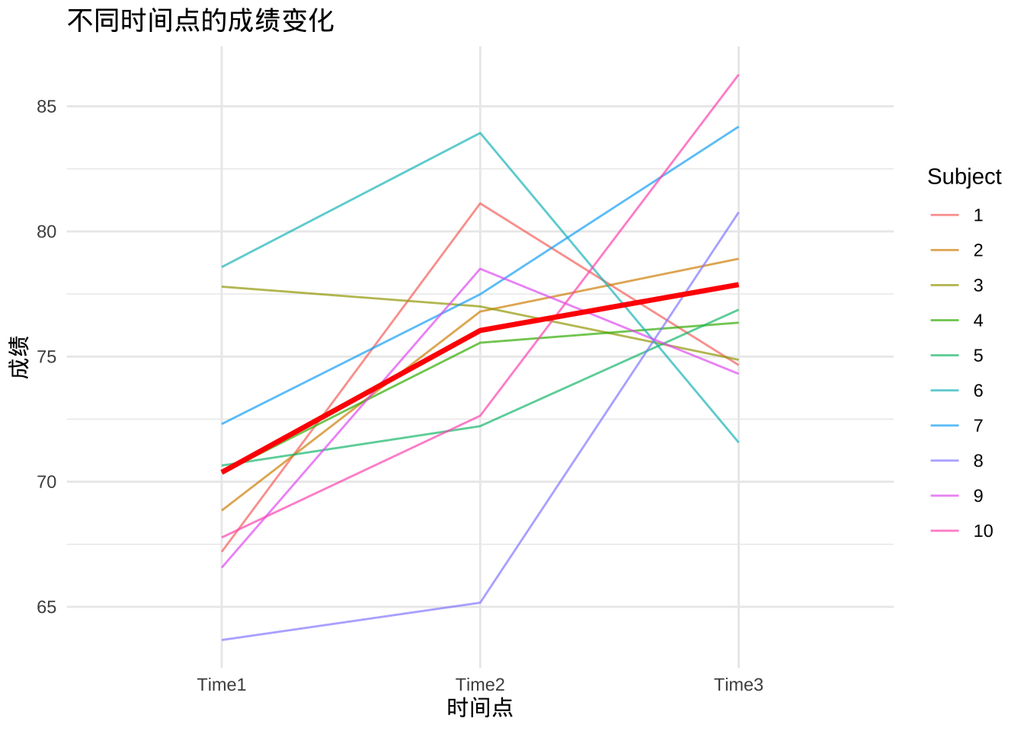

```r
# 绘制均值变化图
ggplot(long_data, aes(x = Time, y = Score, group = Subject)) +
  geom_line(aes(color = Subject), alpha = 0.7) +
  stat_summary(fun = mean, geom = "line", aes(group = 1), linewidth = 1.2, color = "red") +
  labs(title = "不同时间点的成绩变化", x = "时间点", y = "成绩") +
  theme_minimal()
```

上述代码将绘制各个个体在不同时间点的变化曲线，同时用红色粗线表示各时间点的平均值变化，帮助更直观地观察总体趋势。

### 事后分析（进一步分析）

如果不同时间点的均值间差异具有显著性，可以进一步进行事后分析（post-hoc analysis）以确定具体哪些时间点之间存在显著差异。可以使用`pairwise.t.test()`或`TukeyHSD()`等方法进行配对比较，来详细探索不同条件之间的差异。

例如，使用`pairwise.t.test()`进行配对t检验：

```r
# 进行配对t检验
pairwise_result <- pairwise.t.test(long_data$Score, long_data$Time, paired = TRUE)

# 输出结果
print(pairwise_result)
```

```
##
##  Pairwise comparisons using paired t tests
##
## data:  long_data$Score and long_data$Time
##
##       Time1 Time2
## Time2 0.011 -
## Time3 0.030 0.523
##
## P value adjustment method: holm
```

该代码可以帮助识别具体哪些时间点之间的均值差异是显著的。如果某些时间点之间的p值小于0.05，则可以认为这些时间点之间存在显著差异。

## 7 小结

- 重复测量方差分析用于比较同一组个体在不同时间点或条件下的均值差异。
- 适用于需要控制个体间差异的实验设计，例如医学、教育和心理学研究。
- 具有控制个体差异、提高统计效能的优点，但对顺序效应和数据缺失敏感。
- 可以通过R中的`aov()`函数实现，并结合可视化更直观地展示结果。
- 在医学、心理学、教育等多个领域有着广泛的应用价值。